# Analyze Data

### Analyzing usage between Customer's and Subscriber's

#### When looking at the raw set of data the main aspect of this data was the difference in users between customers and subscribers and the months when the bikes are rode

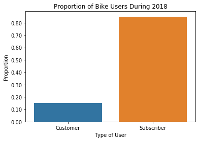

```python
type_count = bikedf.user_type.value_counts()
type_order = type_count.index

n_users = bikedf.shape[0]
max_user_count = type_count[1]
maxprop = max_user_count / n_users
tick_props = np.arange(0, maxprop, 0.1)
tick_names = ['{:0.02f}'.format(v) for v in tick_props]

sb.countplot(x = bikedf.user_type)
plt.yticks(tick_props * n_users, tick_names)
plt.title('Proportion of Bike Users During 2018')
plt.xlabel('Type of User')
plt.ylabel('Proportion');
```

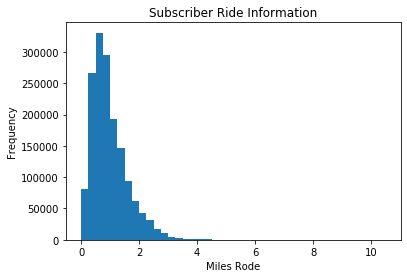

```python
sub_users = bikedf.query("user_type == 'Subscriber'")

bins = np.arange(0,sub_users['miles_traveled'].max()+0.25, 0.25)
plt.hist(sub_users.miles_traveled, bins = bins)
plt.title('Subscriber Ride Information')
plt.xlabel('Miles Rode')
plt.ylabel('Frequency');
```

#### When looking at the distribution, we can see that subscribers are taking rides between 0 and 4 miles which might be due to commuting around the city of San Francisco

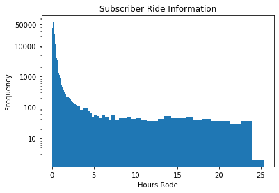

```python
subhours_bins = 10 ** np.arange(-1.770973,1.3796 +0.025, 0.025)
ticks = [10,100,1000,10000, 50000]
labels = ['{}'.format(v) for v in ticks]
plt.hist(sub_users.duration_hours, bins = subhours_bins,log = True)
plt.yticks(ticks, labels)
plt.title('Subscriber Ride Information')
plt.xlabel('Hours Rode')
plt.ylabel('Frequency');
```

#### This also shows that 75% subscribers will ride approximately 20 minutes at a time

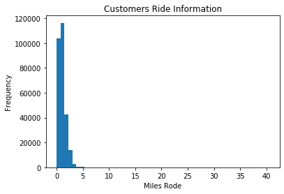

```python
cus_users = bikedf.query("user_type == 'Customer'")
cbins = np.arange(0,cus_users['miles_traveled'].max(), 0.75)
plt.hist(cus_users.miles_traveled, bins = cbins)
plt.title('Customers Ride Information')
plt.xlabel('Miles Rode')
plt.ylabel('Frequency');
```

#### On average 75% of customers will ride 1.4 miles

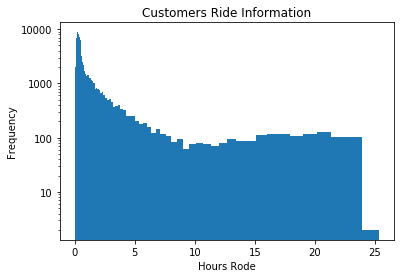

```python
cushours_bins = 10 ** np.arange(-1.770973,1.38 +0.025, 0.025)
ticks = [10,100,1000,10000]
labels = ['{}'.format(v) for v in ticks]
plt.hist(cus_users.duration_hours, bins = cushours_bins,log = True)
plt.yticks(ticks, labels)
plt.title('Customers Ride Information')
plt.xlabel('Hours Rode')
plt.ylabel('Frequency');
```

#### This shows that a majority of riders will ride between 0 and 4 miles which might mean that customers are traveing to the city to take in the sights

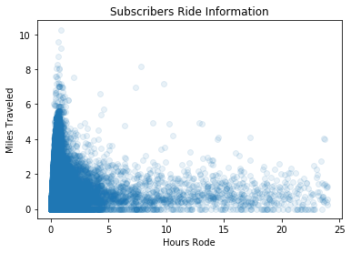

```python
plt.scatter(data = sub_users, x = 'duration_hours', y = 'miles_traveled', alpha = 0.1)
plt.title('Subscribers Ride Information')
plt.xlabel('Hours Rode')
plt.ylabel('Miles Traveled');
```

#### As we can see the density of this chart shows subscribers riding for a shorter period of time

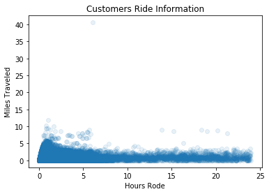

```python
plt.scatter(data = cus_users, x = 'duration_hours', y = 'miles_traveled', alpha = 0.1)
plt.title('Customers Ride Information')
plt.xlabel('Hours Rode')
plt.ylabel('Miles Traveled');
```

#### Customers on the other hand ride for longer periods of time which means it can be for leisure and not a commute to work

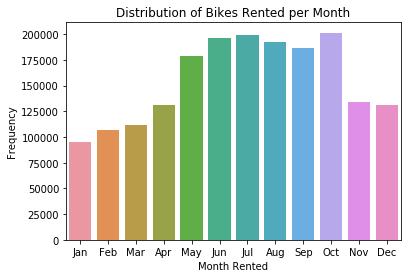

```python
sb.countplot(bikedf.month_rented)
plt.title('Distribution of Bikes Rented per Month')
plt.xlabel('Month Rented')
plt.ylabel('Frequency');
```

#### This shows the distribution of bikes rode per month which makes sense when in the colder weather people will not ride as often

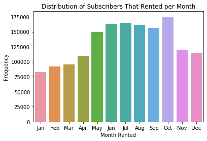

```python
sb.countplot(sub_users.month_rented)
plt.title('Distribution of Subscribers That Rented per Month')
plt.xlabel('Month Rented')
plt.ylabel('Frequency');
```

#### But we can see that even 75,000 subcribers can be commuting to work even in January

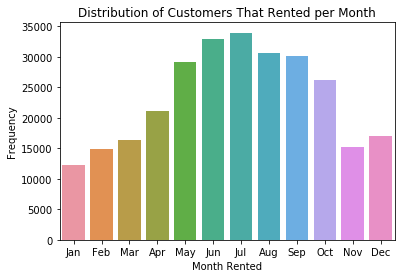

```python
sb.countplot(cus_users.month_rented)
plt.title('Distribution of Customers That Rented per Month')
plt.xlabel('Month Rented')
plt.ylabel('Frequency');
```

#### While just over 10,000 customers are riding in the month of January

[output not shown]

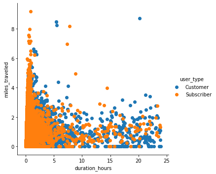

```python
offmonth = ['Jan', 'Feb', 'Mar','Nov','Dec']
off_season = bikedf.query("month_rented == 'Jan'or month_rented == 'Feb' or month_rented == 'Dec'")

g = sb.FacetGrid(data= off_season, hue = 'user_type', size = 5, hue_order = ['Customer', 'Subscriber'])
g.map(plt.scatter, 'duration_hours', 'miles_traveled')
g.add_legend();
```

#### Lastly this chart shows that subscribers are traveling way more on the off season months. But customers are still riding the bikes for more hours throughout the winter months